# Semester Project

Author

Demonstration

## Introduction

In this project, I perform a preliminary investigation of the relationship between Participatory Democracy and Access to Justice for Women. While access to justice and gender equality are both elements of a modern liberal democracy, my research question is whether the participatory aspect of democracy encourages of discourages gender equality in access to justice. I do not examine any control variables or other aspects of democracy, so this is purely a preliminary investigation to establish that the expected relationship exists.

This relationship is important because of the normative importance of gender equality and the practical importance for gender equality of first establishing the most basic level of equality before the law. It should be apparent that full politics rights for half the population is a bare minimum for a modern liberal democracy, but until just over a hundred years ago even voting rights were denied to women in most Protestant democracies and until after World War II in many Catholic democracies.[^1] Welzel, Norris, and Inglehart (ibid.) argue that the improvement in women’s political rights is not merely a result of improvements in democracy, but part of a broader cultural movement. My ultimate question is how important the level of participatory democracy is as either a mediator or moderator of that cultural movement.

```r
# load the data

demonstration_data <- read.csv("demonstration_data.csv")


# subset data to columns 1, 2, 3, 8, 16
demonstration_data <- demonstration_data[,c(1,2,3,8,16)]


cat("Table 1: Data for Demonstration Project")
```

```
Table 1: Data for Demonstration Project
```

```r
# display the first 6 rows of the data
head(demonstration_data)
```

```
     X country_name country_text_id v2x_partipdem v2clacjstw
1  230       Mexico             MEX         0.426     -0.397
2  353     Suriname             SUR         0.484      1.331
3  587       Sweden             SWE         0.659      3.069
4  812  Switzerland             CHE         0.812      3.428
5  933        Ghana             GHA         0.387      1.727
6 1056 South Africa             ZAF         0.480      1.676
```

The data is a crossnational subset of the data from the Varieties of Democracy Project V-Dem version 13 containing for a single year 2018 and includes 179 country observations.[^2] The unit of observation is the country. The chosen variables are the Participatory Democracy Index (*v2x_partipdem*) and Women’s Access to Justice (*v2clacjstw*). The data is derived from expert surveys using the V-Dem Project Methodology.[^3]

## Summary Statistices of the variables

```r
# summary statistics of Y variable

cat("Table 2: Summary statistics of Women's Access to Justice")
```

```
Table 2: Summary statistics of Women's Access to Justice
```

```r
summary(demonstration_data$v2clacjstw)
```

```
   Min. 1st Qu.  Median    Mean 3rd Qu.    Max.
-2.5770 -0.1185  0.9140  0.8240  1.7295  3.9320
```

```r
# variance and standard deviation of Y variable

cat("Table 3: Variance of Women's Access to Justice")
```

```
Table 3: Variance of Women's Access to Justice
```

```r
var(demonstration_data$v2clacjstw)
```

```
[1] 1.690575
```

```r
cat("Table 4: Standard Deviation of Women's Access to Justice")
```

```
Table 4: Standard Deviation of Women's Access to Justice
```

```r
sd(demonstration_data$v2clacjstw)
```

```
[1] 1.300221
```

```r
# summary statistics of X variable

cat("Table 5: Summary Statistics for Participatory Democracy Index")
```

```
Table 5: Summary Statistics for Participatory Democracy Index
```

```r
summary(demonstration_data$v2x_partipdem)
```

```
   Min. 1st Qu.  Median    Mean 3rd Qu.    Max.
 0.0090  0.1680  0.3300  0.3376  0.4815  0.8120
```

```r
# variance and standard deviation of X variable

cat("Table 6: Variance of Participatory Democracy Index")
```

```
Table 6: Variance of Participatory Democracy Index
```

```r
var(demonstration_data$v2x_partipdem)
```

```
[1] 0.03930313
```

```r
cat("Table 7: Standard Deviation of Participatory Democracy Index")
```

```
Table 7: Standard Deviation of Participatory Democracy Index
```

```r
sd(demonstration_data$v2x_partipdem)
```

```
[1] 0.1982502
```

## Histograms of the variables

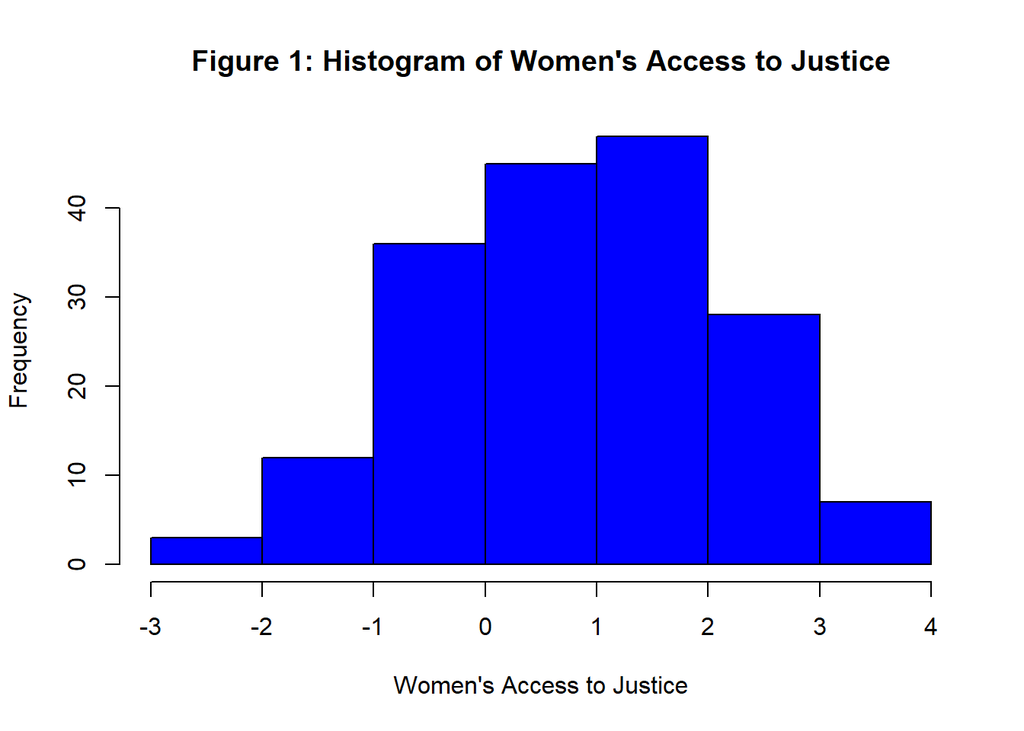

```r
# Histogram of Y variable

hist(demonstration_data$v2clacjstw, col = "blue", main = "Figure 1: Histogram of Women's Access to Justice", xlab = "Women's Access to Justice")
```

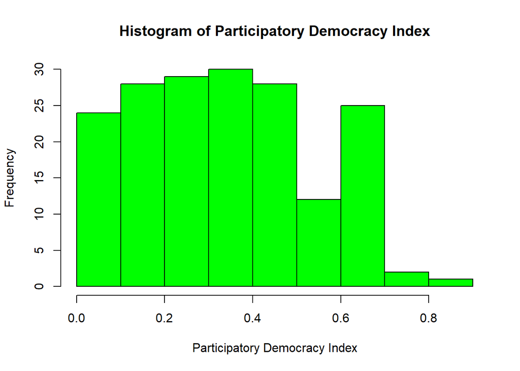

```r
# Histogram of X variable

hist(demonstration_data$v2x_partipdem, col = "green", main = "Histogram of Participatory Democracy Index", xlab = "Participatory Democracy Index")
```

```r
# Histogram of additional variables if needed
```

## The Relationship between the variables

Participatory Democracy and Women’s Access to Justice show a clear relationship. The covariance of the variables is 0.203. The Pearson’s correlation of the two variables is quite strong at 0.788 (See Table 8).

```r
library(stargazer)
# correlation between variables
varcor <- cor(demonstration_data$v2clacjstw, demonstration_data$v2x_partipdem)


#covariance between variables
varcov <- cov(demonstration_data$v2clacjstw, demonstration_data$v2x_partipdem)


# correlation and covariance table
corcov <- cbind(varcor, varcov)
stargazer(corcov, type = "text", title = "Table 8: Correlation and Covariance of Variables")
```

```
Table 8: Correlation and Covariance of Variables
=============
varcor varcov
-------------
0.788  0.203
-------------
```

## Regression Results

```r
# OLS regression model

#define model object using lm()
model_object1 <- lm(v2clacjstw ~ v2x_partipdem, data = demonstration_data)

# stargazer table of model
library(stargazer)
stargazer(model_object1, type = "text", title = "Table 9: OLS Regression Results", covariate.labels = "Participatory Democracy Index",dep.var.labels = "Women's Access to Justice")
```

```
Table 9: OLS Regression Results
=========================================================
                                  Dependent variable:
                              ---------------------------
                               Women's Access to Justice
---------------------------------------------------------
Participatory Democracy Index          5.167***
                                        (0.304)

Constant                               -0.920***
                                        (0.119)

---------------------------------------------------------
Observations                              179
R2                                       0.621
Adjusted R2                              0.618
Residual Std. Error                0.803 (df = 177)
F Statistic                    289.555*** (df = 1; 177)
=========================================================
Note:                         *p<0.1; **p<0.05; ***p<0.01
```

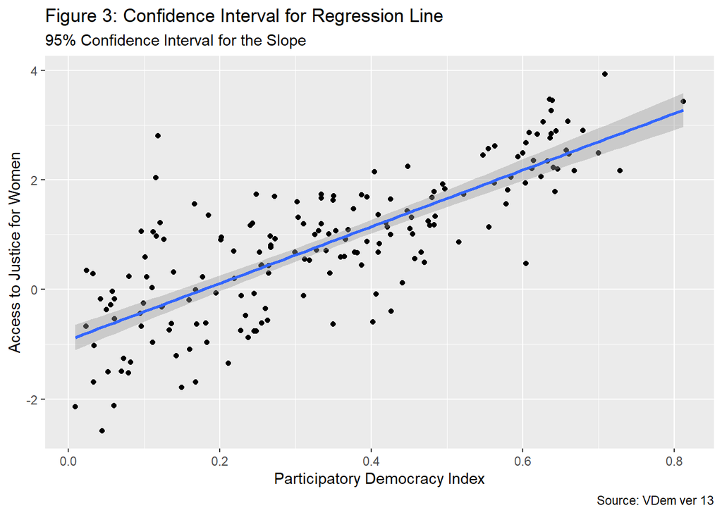

```r
# plot of model results with confidence intervals
library(ggplot2)


ggplot(data = demonstration_data, aes(x = v2x_partipdem, y = v2clacjstw)) +
  geom_point() +
  geom_smooth(method = "lm", se = TRUE) +
  labs(title = "Figure 3: Confidence Interval for Regression Line",
       subtitle = "95% Confidence Interval for the Slope",
       caption = "Source: VDem ver 13") +
        xlab("Participatory Democracy Index") +
        ylab("Access to Justice for Women")
```

A simple univariate Ordinary Least SQuares regression model shows a strong effect of Participatory Democracy on Women’s Access to Justice. The coefficient is 5.167, indicating that an increase of one in the Participatory Democracy Index yields an increase of 5.167 in Women’s Access to Justice (see Table 9).[^4] The result is significant at the 0.01 level. There is a strong linear relationship with a high degree of confidence (see Figure 3). The model has an Adjusted $R^2$ of 0.618, explaining 61.8/% of the dependent variable. The model has an excellent fit with an F-Statistic significant at the .01 level.

## Conclusion

The results were not surprising, confirming the expected relationship. No controls were used and nothing was done to determine the direction of causation. The questions suggested by the Welzel, Norris, and Inglehart research (ibid.) suggest that both increases in Participatory Democracy and Women’s Access to Justice may be caused by some third cultural variable. It is possible that increased legal rights for women increase participatory democracy. At a minimum in future work, the other democracy indexes from VDem should be included along with the measures used in the Welzel, Norris, and Inglehart research. A more robust model would include additional controls and might include an instrument for the Participatory Democracy index.

## Footnotes

[^1]: Welzel C, Norris P and Inglehart R (2002) Gender equality and democracy. Comparative sociology 1(3-4). Brill: 321–345.
[^2]: Michael Coppedge, John Gerring, Carl Henrik Knutsen, Staffan I. Lindberg, Jan Teorell, David Altman, Michael Bernhard, M. Steven Fish, Adam Glynn, Allen Hicken, Anna Lührmann, Kyle L. Marquardt, Kelly McMann, Pamela Paxton, Daniel Pemstein, Brigitte Seim, Rachel Sigman, Svend-Erik Skaaning, Jeffrey Staton, Natalia Stepanova, and Yi-ting Wang. 2020. “V-Dem [Country-Year/Country-Date] Dataset v10.” Varieties of Democracy (V-Dem) Project. https://doi.org/10.23696/vdemds10.
[^3]: Pemstein, Daniel, Kyle L. Marquardt, Eitan Tzelgov, Yi-ting Wang, Juraj Medzihorsky, Joshua Krusell, Farhad Miri, and Johannes von Römer. 2023. “The V-Dem Measurement Model: Latent Variable Analysis for Cross-National and Cross-Temporal Expert-Coded Data”. V-Dem Working Paper No. 21. 8th edition. University of Gothenburg: Varieties of Democracy Institute.
[^4]: It is worth noting that the maximum value of Participatory Democracy Index is 0.8120 and minimum is 0.0090, while the maximum Women’s Access to Justice is 3.9320 and minimum is -2.5770. See Tables 2 and 5.